# Igniting full-length isoform and mutation analysis of single-cell RNA-seq data with FLAMES

# 6 Data pre-processing

```r
sce <- qs::qread(system.file("extdata", "sce.qs", package = "IgniteRNAseq"))
sce
```

```
## class: SingleCellExperiment
## dim: 15076 162
## metadata(1): OutputFiles
## assays(1): counts
## rownames(15076): ENSG00000000419.14_50934870_50958532_1
##   ENSG00000001036.14_143495487_143511720_2 ... ENST00000713574.1
##   ENST00000713579.1
## rowData names(3): transcript_id gene_id FSM_match
## colnames(162): AAAGAACAGCGATCGA AACAGGGTCCAGTGCG ... TTTCAGTCACCAGTAT
##   TTTGGAGCACAAAGTA
## colData names(0):
## reducedDimNames(0):
## mainExpName: NULL
## altExpNames(1): gene
```

```r
altExp(sce, 'gene')
```

```
## class: SingleCellExperiment
## dim: 14555 162
## metadata(0):
## assays(1): counts
## rownames(14555): ENSG00000179820.16 ENSG00000114062.22 ... ENSG00000212907.2
##   ENSG00000228253.1
## rowData names(0):
## colnames(162): AAAGAACAGCGATCGA AACAGGGTCCAGTGCG ... TTTCAGTCACCAGTAT
##   TTTGGAGCACAAAGTA
## colData names(0):
## reducedDimNames(0):
## mainExpName: NULL
## altExpNames(0):
```

We can use Bioconductor packages for normalization, dimensionality reduction and clustering:

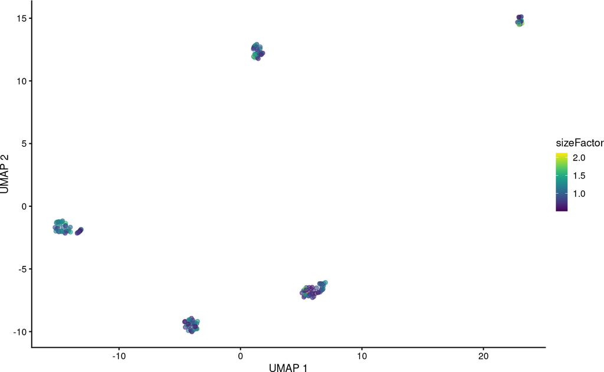

```r
altExp(sce, 'gene') <- altExp(sce, 'gene') |>
  scuttle::logNormCounts() |>
  scater::runPCA() |>
  scater::runUMAP()

sce$cluster <- scran::buildSNNGraph(altExp(sce, 'gene')) |>
  igraph::cluster_leiden() |>
  igraph::membership() |>
  factor()

altExp(sce, 'gene')$cluster <- sce$cluster

scater::plotReducedDim(altExp(sce, 'gene'), 'UMAP', colour_by = 'sizeFactor')
```

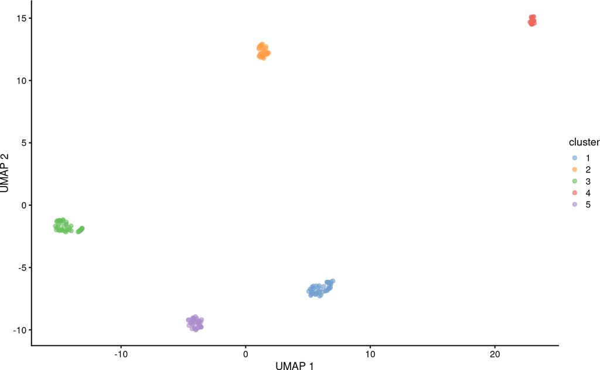

```r
scater::plotReducedDim(altExp(sce, 'gene'), 'UMAP', colour_by = 'cluster')
```

# 7 Mutation analysis

## 7.1 Mutation discovery

Next, we get the bulk allele count to see if there is any potential SNP mutation in our data.

```r
mutation_discovery_tb <- FLAMES::find_variants(
  'filtered_sorted.bam',
  'subset_GRCh38.fa',
  system.file("extdata", "filtered.gtf", package = "IgniteRNAseq"),
  min_nucleotide_depth = 100,
  homopolymer_window = 3,
  annotated_region_only = TRUE,
  names_from = "gene_name",
  threads = 4
)
```

```
## 02:04:21 Got 1 bam file, parallelizing over each region ...
```

```
## 02:05:49 Merging results ...
```

```
## 02:05:49 Calculating homopolymer percentages ...
```

```r
mutation_discovery_tb
```

```
## # A tibble: 1,088 × 10
##    seqnames   pos nucleotide count    sum     freq ref   bam_path   region homopolymer_pct
##    <fct>    <dbl> <fct>      <int>  <dbl>    <dbl> <fct> <chr>      <chr>            <dbl>
##  1 chrM      7021 +           1553 249499 0.00622  T     filtered_… MT-CO1           0.333
##  2 chrM      7020 -           1888 249484 0.00757  G     filtered_… MT-CO1           0.5
##  3 chrM      7020 A           1632 249484 0.00654  G     filtered_… MT-CO1           0.5
##  4 chrM      7020 C            117 249484 0.000469 G     filtered_… MT-CO1           0.5
##  5 chrM      7020 T            457 249484 0.00183  G     filtered_… MT-CO1           0.5
##  6 chrM      7022 +            565 249539 0.00226  T     filtered_… MT-CO1           0.333
##  7 chrM      7021 -           2293 249499 0.00919  T     filtered_… MT-CO1           0.333
##  8 chrM      7021 A            432 249499 0.00173  T     filtered_… MT-CO1           0.333
##  9 chrM      7021 C           2509 249499 0.0101   T     filtered_… MT-CO1           0.333
## 10 chrM      7021 G           1160 249499 0.00465  T     filtered_… MT-CO1           0.333
## # ℹ 1,078 more rows
```

```r
mutation_discovery_tb <- mutation_discovery_tb |>
  filter(freq > 0.2, freq < 0.8) |>
  arrange(desc(count))

mutation_discovery_tb
```

```
## # A tibble: 6 × 10
##   seqnames      pos nucleotide  count    sum  freq ref     bam_path region homopolymer_pct
##   <fct>       <dbl> <fct>       <int>  <dbl> <dbl> <fct>   <chr>    <chr>            <dbl>
## 1 chrM         7028 T          130634 249993 0.523 C       filtere… MT-CO1           0.5
## 2 chrM         8251 A          104893 266526 0.394 G       filtere… MT-CO2           0.5
## 3 chr19    48965830 C           85423 178620 0.478 charac… filtere… FTL           -Inf
## 4 chr19    48965830 T           84346 178620 0.472 charac… filtere… FTL           -Inf
## 5 chrM         9123 A           66376 220334 0.301 G       filtere… MT-AT…           0.333
## 6 chrM        11719 A           51284 151846 0.338 G       filtere… MT-ND4           0.333
```

As we can see, there is a couple of potential SNP mutations, let’s see if they are correlated with our clustering.

## 7.2 Mutation calling

`FLAMES` offers the `sc_mutations` function to call mutations at the single-cell level:

```r
snps_tb <- FLAMES::sc_mutations(
  'filtered_sorted.bam',
  seqnames = as.character(mutation_discovery_tb$seqnames),
  positions = mutation_discovery_tb$pos,
  indel = F,
  barcodes = colnames(sce),
  threads = 4
)
```

```
## 02:06:18 Got 1 bam file, parallelizing over each position ...
```

```
## 02:07:48 Merging results ...
```

Lets visualize the SNPs on our previous UMAP:

```r
head(snps_tb)
```

```
## # A tibble: 6 × 7
##   allele barcode          allele_count cell_total_reads     pct   pos seqname
##   <chr>  <chr>                   <dbl>            <dbl>   <dbl> <dbl> <chr>
## 1 A      AAAGAACAGCGATCGA            0             1030 0        7028 chrM
## 2 A      AACAGGGTCCAGTGCG            2             1649 0.00121  7028 chrM
## 3 A      AAGTCGTCAGTAGGAC            9             2299 0.00391  7028 chrM
## 4 A      AATCACGGTCCTCCTA            7             1728 0.00405  7028 chrM
## 5 A      AATCGACAGGGTGGGA            5             1611 0.00310  7028 chrM
## 6 A      AATCGACTCGTTTACT            2             1196 0.00167  7028 chrM
```

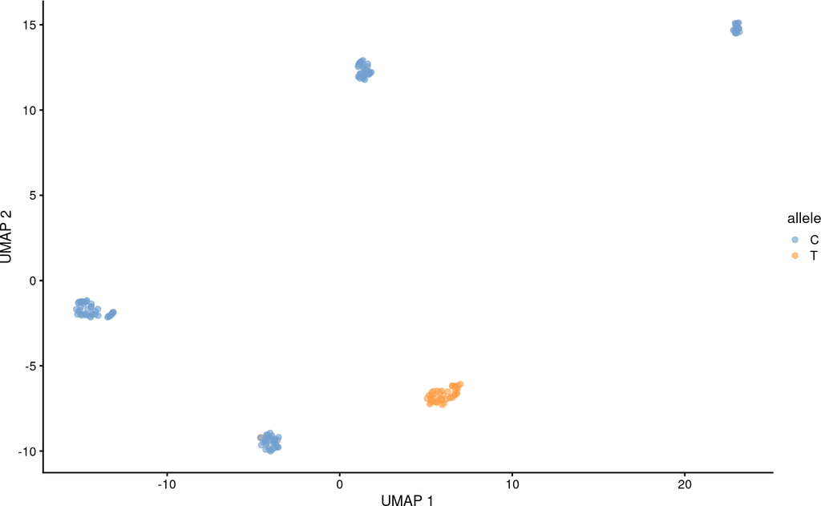

```r
chr19 <- snps_tb |>
  filter(allele_count > 0, pct > 0.5) |>
  filter(seqname == 'chr19', pos == 48965830)
chr19 <- chr19[match(colnames(sce), chr19$barcode),"allele"] |>
 as.data.frame()
scater::plotReducedDim(altExp(sce, 'gene'), 'UMAP', colour_by = chr19)
```

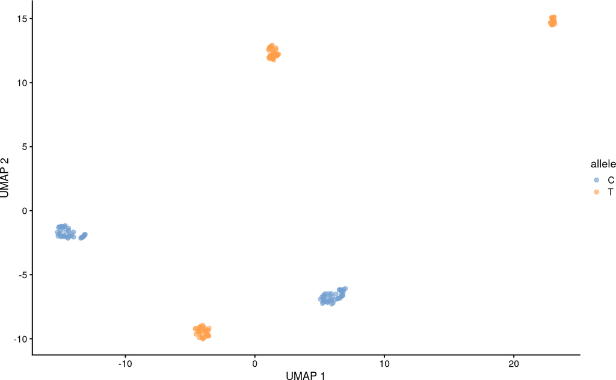

```r
chrM_7028 <- snps_tb |>
  filter(allele_count > 0, pct > 0.5) |>
  filter(seqname == 'chrM', pos == 7028)
chrM_7028 <- chrM_7028[match(colnames(sce), chrM_7028$barcode),"allele"] |>
 as.data.frame()
scater::plotReducedDim(altExp(sce, 'gene'), 'UMAP', colour_by = chrM_7028)
```

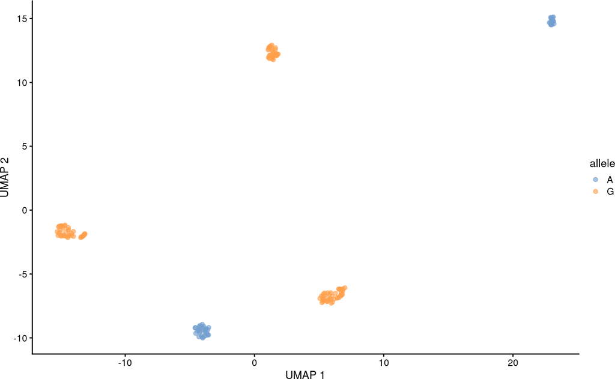

```r
chrM_8251 <- snps_tb |>
  filter(allele_count > 0, pct > 0.5) |>
  filter(seqname == 'chrM', pos == 8251)
chrM_8251 <- chrM_8251[match(colnames(sce), chrM_8251$barcode),"allele"] |>
 as.data.frame()
scater::plotReducedDim(altExp(sce, 'gene'), 'UMAP', colour_by = chrM_8251)
```

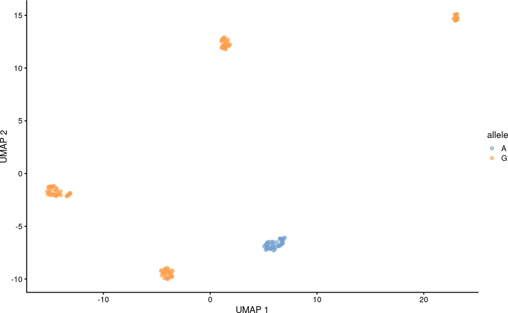

```r
chrM_9123 <- snps_tb |>
  filter(allele_count > 0, pct > 0.5) |>
  filter(seqname == 'chrM', pos == 9123)
chrM_9123 <- chrM_9123[match(colnames(sce), chrM_9123$barcode),"allele"] |>
 as.data.frame()
scater::plotReducedDim(altExp(sce, 'gene'), 'UMAP', colour_by = chrM_9123)
```

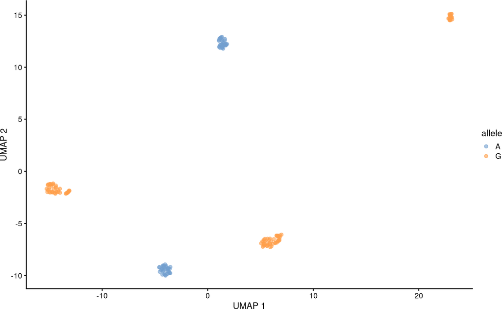

```r
chrM_11719 <- snps_tb |>
  filter(allele_count > 0, pct > 0.5) |>
  filter(seqname == 'chrM', pos == 11719)
chrM_11719 <- chrM_11719[match(colnames(sce), chrM_11719$barcode),"allele"] |>
 as.data.frame()
scater::plotReducedDim(altExp(sce, 'gene'), 'UMAP', colour_by = chrM_11719)
```

# 8 Differential Transcript Experssion analysis

Since we have the transcript count matrix from `FLAMES`, we can do some DTE analysis:

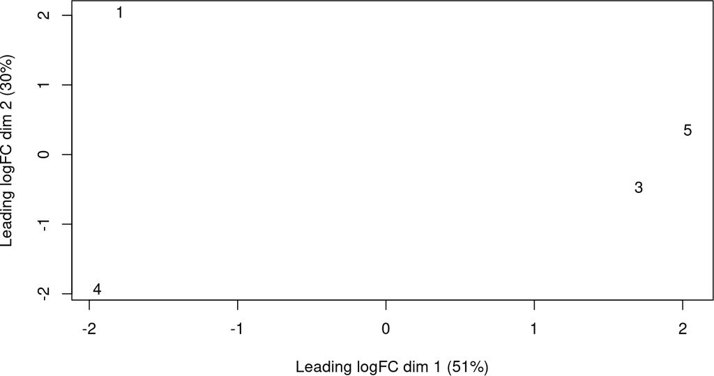

```r
pseudo_bulk <- counts(sce) |>
    t() |>
    as.matrix() |>
    by(sce$cluster, colSums) |>
    sapply(identity) |>
    by(rownames(counts(sce)), colSums) |>
    sapply(identity) |>
    t()

dgelist <- DGEList(
  counts = pseudo_bulk[, -2],
  group = factor(c("A", "B", "A", "B"))
)
dgelist <- dgelist[
  filterByExpr(dgelist), , # bias?
  keep.lib.sizes = FALSE
]
plotMDS(dgelist)
```

```r
dgelist <- calcNormFactors(dgelist, method = "TMM")
# means model
design <- model.matrix(~ 0 + dgelist$samples$group, data = dgelist$samples)
colnames(design) <- gsub(".*\\$", "", colnames(design)) |>
  gsub(" .*$", "", x = _)
dge_v <- voom(dgelist, design, save.plot = T, plot = F, span = 0.2)
efit <- lmFit(dge_v, dge_v$design) |>
  contrasts.fit(contrasts = makeContrasts(
    MalevsFemale = "groupA - groupB",
    levels = dge_v$design
  )) |>
  eBayes()
topTable(efit)
```

```
##                    logFC AveExpr      t  P.Value adj.P.Val    B
## ENST00000621160.5  -7.20    7.01 -11.71 1.29e-06    0.0103 5.15
## ENST00000284440.9   5.95    6.64  11.00 2.15e-06    0.0103 4.92
## ENST00000618200.4  -7.91    6.81 -11.03 2.10e-06    0.0103 4.46
## ENST00000649529.1  -5.55    7.65  -9.11 9.85e-06    0.0289 3.80
## ENST00000316403.15  5.12    5.99   8.87 1.21e-05    0.0289 3.58
## ENST00000412585.7  -4.57    6.00  -8.60 1.55e-05    0.0306 3.37
## ENST00000361157.11 -4.61    6.96  -8.41 1.85e-05    0.0306 3.27
## ENST00000361566.7  -5.38    8.03  -8.29 2.06e-05    0.0306 3.19
## ENST00000378292.9   6.48    5.22   9.03 1.05e-05    0.0289 3.18
## ENST00000368716.9   4.90    6.44   8.25 2.14e-05    0.0306 3.14
```

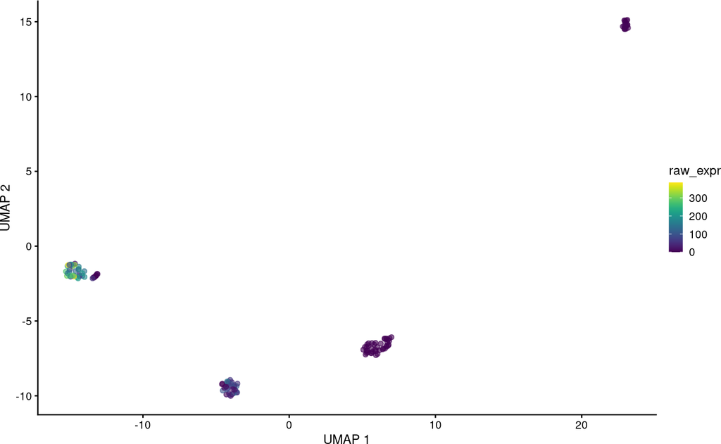

```r
scater::plotReducedDim(altExp(sce[, sce$cluster != 2], 'gene'), 'UMAP',
                       colour_by = data.frame(raw_expr = counts(sce)['ENST00000621160.5', sce$cluster != 2]))
```

# 9 Differential Transcript Usage analysis

```r
sce@metadata$OutputFiles$outdir <- tempdir()
download.file('https://zenodo.org/records/12751214/files/isoform_FSM_annotation.csv?download=1',
              file.path(sce@metadata$OutputFiles$outdir, "isoform_FSM_annotation.csv"))

colLabels(sce) <- sce$cluster
dtu_df <- sc_DTU_analysis(sce)
```

```
## Loading isoform_FSM_annotation.csv ...
## Selecting transcript_ids with full splice match ...
## Summing transcripts with same FSM ...
## Creating FSM_count.csv.gz ...
## /vast/scratch/users/wang.ch/posit/Rtmp4FnnWf/FSM_count.csv.gz saved.
##   12340 FSM_match(s) found.
## Filtering for genes with at least 2 detected isforms ...      8895 FSM_match(s) left.
## Keeping only the top 4 expressed FSM_matches for each gene ...      7783 FSM_match(s) left.
## Aggregating counts by cluster labels ...
## Filtering isoforms ... 7783  transcript_id(s) remaining.
## Performing Chi-square tests ...
##
```

```
## Results saved to  /vast/scratch/users/wang.ch/posit/Rtmp4FnnWf/sc_DTU_analysis.csv
```